# Machine learning algorithm to predict how well barbell lifts is performed

Luca Valer

# Executive Summary

In this project we are going to use Machine learning algorithm to predict the manner in which a group of individual perform barbell lifts. By using data from accelerometers on the belt, forearm, arm, and dumbell we are going to learn how individual do exercise correctly and incorrectly in 5 different ways. The data is collected with devices such as Jawbone Up, Nike FuelBand, and Fitbit and it is now possible to collect a large amount of data about personal activity relatively inexpensively. These type of devices are part of the quantified self-movement.

We are going to use Random forest algorithm on the “classe” variable within the training set. Once the model is built we will then predict the 20 different cases in the test data set. More information is available from the website here: http://groupware.les.inf.puc-rio.br/har (see the section on the Weight Lifting Exercise Dataset).

# Data

The training data for this project are available here:

https://d396qusza40orc.cloudfront.net/predmachlearn/pml-training.csv

The test data are available here:

https://d396qusza40orc.cloudfront.net/predmachlearn/pml-testing.csv

# Exploring the data

we start with loading the libraries we will beed

```r
library(lattice)
library(ggplot2)
library(data.table)
library(caret)
library(randomForest)
```

We now load the two datasets into tran and test.

```r
train = read.csv("./data/pml-training.csv", na.strings = c("NA","#DIV/0!", ""))
test = read.csv("./data/pml-testing.csv", na.strings = c("NA","#DIV/0!", ""))
dim(train)
```

```
## [1] 19622   160
```

The train data set contains 19622 records in 160 columns.

Let’s look at the variables:

```r
str(train)
```

```
## 'data.frame':    19622 obs. of  160 variables:
##  $ X                       : int  1 2 3 4 5 6 7 8 9 10 ...
##  $ user_name               : Factor w/ 6 levels "adelmo","carlitos",..: 2 2 2 2 2 2 2 2 2 2 ...
##  $ raw_timestamp_part_1    : int  1323084231 1323084231 1323084231 1323084232 1323084232 1323084232 1323084232 1323084232 1323084232 1323084232 ...
##  $ raw_timestamp_part_2    : int  788290 808298 820366 120339 196328 304277 368296 440390 484323 484434 ...
##  $ cvtd_timestamp          : Factor w/ 20 levels "02/12/2011 13:32",..: 9 9 9 9 9 9 9 9 9 9 ...
##  $ new_window              : Factor w/ 2 levels "no","yes": 1 1 1 1 1 1 1 1 1 1 ...
##  $ num_window              : int  11 11 11 12 12 12 12 12 12 12 ...
##  $ roll_belt               : num  1.41 1.41 1.42 1.48 1.48 1.45 1.42 1.42 1.43 1.45 ...
##  $ pitch_belt              : num  8.07 8.07 8.07 8.05 8.07 8.06 8.09 8.13 8.16 8.17 ...
##  $ yaw_belt                : num  -94.4 -94.4 -94.4 -94.4 -94.4 -94.4 -94.4 -94.4 -94.4 -94.4 ...
##  $ total_accel_belt        : int  3 3 3 3 3 3 3 3 3 3 ...
##  $ kurtosis_roll_belt      : num  NA NA NA NA NA NA NA NA NA NA ...
##  $ kurtosis_picth_belt     : num  NA NA NA NA NA NA NA NA NA NA ...
##  $ kurtosis_yaw_belt       : logi  NA NA NA NA NA NA ...
```

[output cut: 86 more lines]

There are three main issues with this data set:

1. Not all variables are numeric/integer. Some are Factor and other logic. Those will be removed.
2. Many variables contain large part of data as NA. Those will be removed as they just increase the noise in the prediction
3. the instructions were to predict using only belt, dumbbell, forearm, arm, hence we are going to delete all the other

We are going to remove the unnecessary variables.

```r
# eliminate the non number and columns with NA values
 train.subset <- function(dataset) {
    labels <- dataset$classe
    num <- sapply(dataset, is.numeric)
    dataset <- dataset[, num]
    na <- sapply(dataset, anyNA)
    dataset <- dataset[, !na]
    cbind(dataset, classe = labels)
  }

train <-  train.subset(train)

#eliminated the extra variable
extra.train <- grepl("^X|timestamp|window|user_name", names(train))
train <- train[, !extra.train]

dim(train)
```

```
## [1] 19622    53
```

We have reduced the dataset to 53 variables, 52 are the model predictors.

# Screening for near-zero variance variables

We need to check for zero variance variable and exclude them, in case we find any.

```r
zero.variance <- nearZeroVar(train, saveMetrics=TRUE)
if (any(zero.variance$nzv)) zero.variance else message("No variables with near zero variance")
```

```
## No variables with near zero variance
```

# Model Building

We decided to use random forest model as there was not any specific request on what model to use. The first thing we need to do is partion the data set into two: the Train model and the testing. we are going to allocate 70% of the data into the training set and 30% into the testing one.

```r
set.seed(1000)
Intrain <- createDataPartition(train$classe, p=0.7, list=F)
training.data <- train[Intrain,]
testing.data <- train[-Intrain,]
```

As we move to build the model, we decided to use 250 as number of trees. This gives us a reasonable tradeoff between training time and accuracy.

```r
model.rf<-train(classe ~ ., data=training.data, method="rf", trControl= trainControl(method = "cv", number = 5), ntree=250)
model.rf$finalModel
```

```
##
## Call:
##  randomForest(x = x, y = y, ntree = 250, mtry = param$mtry)
##                Type of random forest: classification
##                      Number of trees: 250
## No. of variables tried at each split: 2
##
##         OOB estimate of  error rate: 0.71%
## Confusion matrix:
##      A    B    C    D    E  class.error
## A 3903    2    0    0    1 0.0007680492
## B   12 2641    5    0    0 0.0063957863
## C    0   22 2370    4    0 0.0108514190
## D    0    0   44 2207    1 0.0199822380
## E    0    0    1    5 2519 0.0023762376
```

# OOB

The OOB (out of bag) estimate of error rate is 0.71% which it is very low.

# Evaluate the model

Firstly, the model is used to predict the outcome in the cross-validation dataset (testing). Secondly, the function confusionMatrix is used to calculate the accuracy and all other metrics of the prediction.

```r
model.testing <- predict(model.rf, newdata = testing.data)
confusionMatrix(data = model.testing, reference = testing.data$classe)
```

```
## Confusion Matrix and Statistics
##
##           Reference
## Prediction    A    B    C    D    E
##          A 1671    6    0    0    0
##          B    3 1132    7    0    0
##          C    0    1 1017   17    1
##          D    0    0    2  946    4
##          E    0    0    0    1 1077
##
## Overall Statistics
##
##                Accuracy : 0.9929
##                  95% CI : (0.9904, 0.9949)
##     No Information Rate : 0.2845
##     P-Value [Acc > NIR] : < 2.2e-16
##
##                   Kappa : 0.991
##  Mcnemar's Test P-Value : NA
##
## Statistics by Class:
##
##                      Class: A Class: B Class: C Class: D Class: E
## Sensitivity            0.9982   0.9939   0.9912   0.9813   0.9954
## Specificity            0.9986   0.9979   0.9961   0.9988   0.9998
## Pos Pred Value         0.9964   0.9912   0.9817   0.9937   0.9991
## Neg Pred Value         0.9993   0.9985   0.9981   0.9964   0.9990
## Prevalence             0.2845   0.1935   0.1743   0.1638   0.1839
## Detection Rate         0.2839   0.1924   0.1728   0.1607   0.1830
## Detection Prevalence   0.2850   0.1941   0.1760   0.1618   0.1832
## Balanced Accuracy      0.9984   0.9959   0.9937   0.9901   0.9976
```

The most important variables in the model and their relative importance values are:

```r
varImp(model.rf)
```

```
## rf variable importance
##
##   only 20 most important variables shown (out of 52)
##
##                   Overall
## roll_belt          100.00
## yaw_belt            86.76
## magnet_dumbbell_z   79.65
## pitch_forearm       71.49
## magnet_dumbbell_y   68.12
## pitch_belt          67.47
## magnet_dumbbell_x   54.18
## accel_belt_z        51.45
## roll_dumbbell       49.78
## accel_dumbbell_y    49.33
## magnet_belt_z       49.23
## roll_forearm        49.19
## magnet_belt_y       48.99
## accel_dumbbell_z    43.49
## roll_arm            41.11
## accel_forearm_x     35.83
## gyros_belt_z        35.76
## yaw_dumbbell        33.03
## accel_dumbbell_x    31.90
## magnet_forearm_x    30.69
```

# Predict variable on the test set

We are going to apply the same to the the test set. fisrt of all we need to apply the same data -cleaning we did to the train set

```r
# eliminate the non numberi and columns with NA values
 test.subset <- function(dataset) {
    labels <- dataset$classe
    num <- sapply(dataset, is.numeric)
    dataset <- dataset[, num]
    na <- sapply(dataset, anyNA)
    dataset <- dataset[, !na]
}

test <-  test.subset(test)
extra.test <- grepl("^X|timestamp|window|user_name|problem_id", names(test))
test <- test[, !extra.test]
dim(test)
```

```
## [1] 20 52
```

The test set has the 52 variable we need for the prediction and 20 rows. We can now apply the model to the test set to predict the 20 values.

```r
Predict.test <- predict(model.rf, test)
Predict.test
```

```
##  [1] B A B A A E D B A A B C B A E E A B B B
## Levels: A B C D E
```

Above the 20 values predicted form the test dataset.

# Appendix

Here the plot of the most important variable in the model

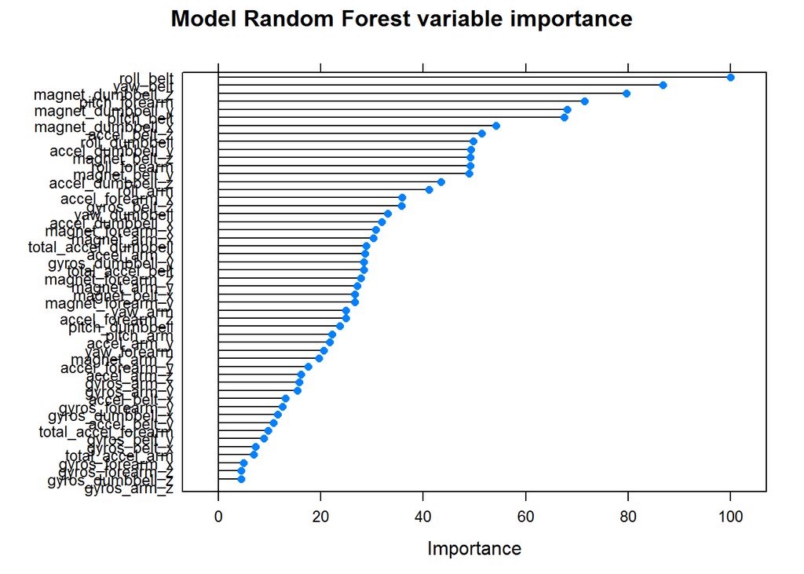

```r
plot(varImp(model.rf),main = "Model Random Forest variable importance")
```